# Efecto de las medidas tomadas por el gobierno peruano frente al COVID-19

### Distrito exclusivos vs empleo

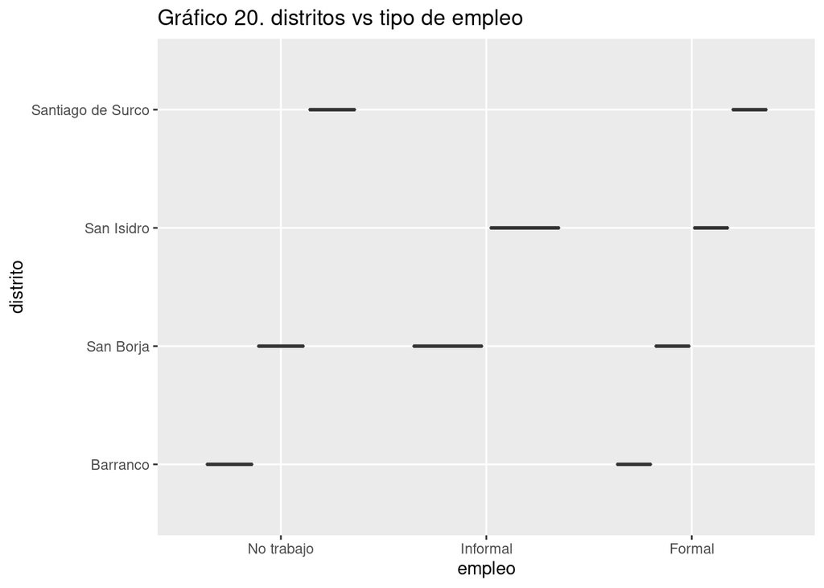

```r
df_form2 %>%
    filter(distrito %in% c("Miraflores",
                           "Barranco",
                           "San Isidro",
                           "Santiago de Surco",
                           "San Borja")
           ) -> df_5
ggplot(aes(y = distrito, x = empleo), data = df_5) +
    geom_boxplot() +
    ggtitle("Gráfico 20. distritos vs tipo de empleo")
```

### Distrito exclusivo vs ingreso

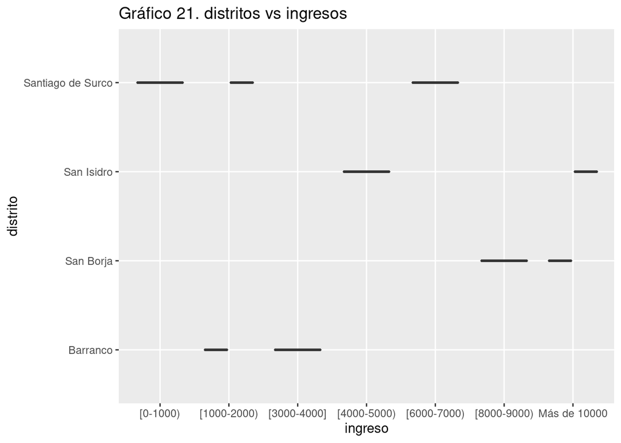

```r
ggplot(aes(y = distrito, x = ingreso), data = df_5) +
    geom_boxplot() +
    ggtitle("Gráfico 21. distritos vs ingresos") # Aún no ha respondido nadie de Miraflores.
```

# Respondiendo las preguntas inferenciales

## ¿La entrega de mayores subsidios monetarios resultaría en un importante beneficio para la disminución del número de salidas?

A partir del gráfico 22 se manifiesta que esta medida, para la población encuestada, no redujo las salidas. Esto respalda las hipótesis que suscitaron en la gráfica 8 y 9, las cuales exponían que aunque el objetivo del padrón de hogares era ayudar a las poblaciones más vulnerables para que puedan acceder a los servicios básicos, el mismo hecho de cobrar hacía que la salidas aumenten. Del mismo modo, la aglomeración resultaría en un aumento del número de contagiados, el cual se muestra claramente en la gráfica 8.

### Entrega de bono S/. 380, S/.760 de acuerdo al Sistema de Focalización de Hogares (SISFOH)

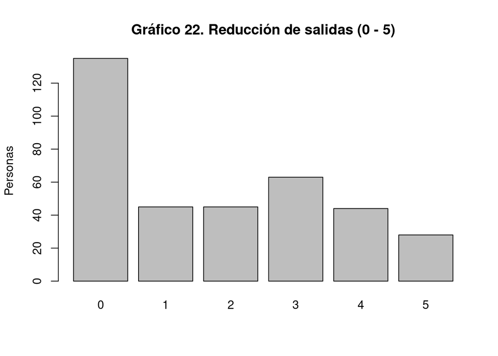

```r
df_form2$bono.05 %>%
    table() %>%
    barplot(ylab="Personas")

title("Gráfico 22. Reducción de salidas (0 - 5)")
```

## Disminución de salidas de las demás medidas

### Inmovilización

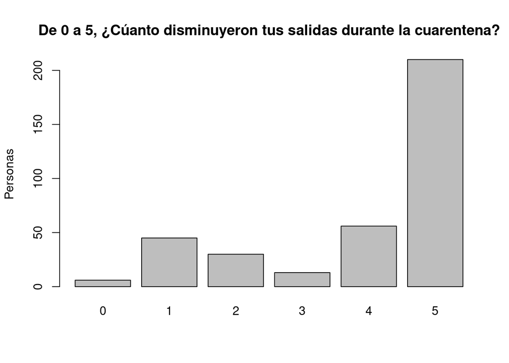

```r
df_form2$social.05 %>%
    table() %>%
    barplot(ylab="Personas")

title("De 0 a 5, ¿Cúanto disminuyeron tus salidas durante la cuarentena?")
```

### Suspensión de acceso a lugares públicos

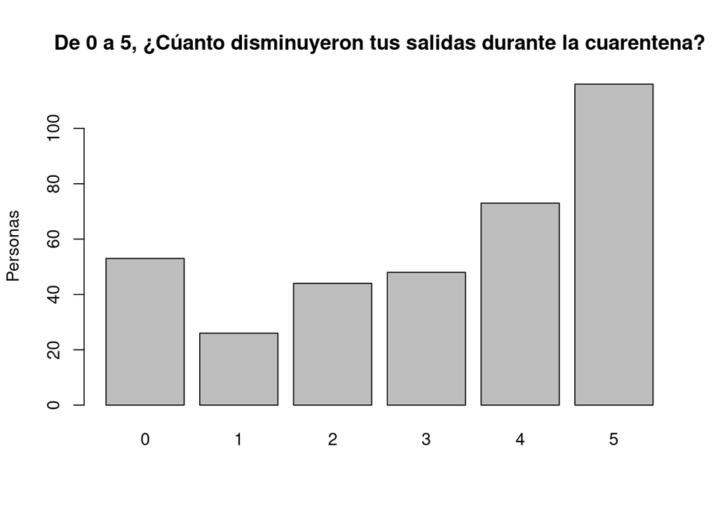

```r
df_form2$ocio.05 %>%
    table() %>%
    barplot(ylab="Personas")

title("De 0 a 5, ¿Cúanto disminuyeron tus salidas durante la cuarentena?")
```

### Disposición salida de hombres y mujeres en días complementarios

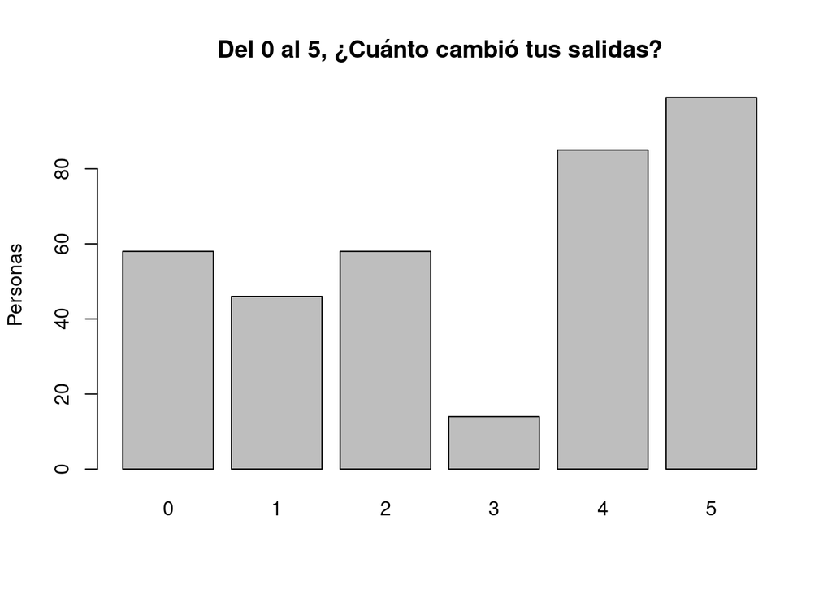

```r
df_form2$noday.05 %>%
    table() %>%
    barplot(ylab="Personas")

title("Del 0 al 5, ¿Cuánto cambió tus salidas?")
```